# Selección de Variables Datos Vino

## Preliminares

En este documento se presentan varias alternativas para las selección automática de variables en modelos de regresión. Esta técnicas automáticas resulta útiles cuando nos enfrentamos a gran cantidad de variables y esto hace que el proceso manual sea difícil de abordar. En cualquier caso, hemos de saber que no son mágicas y que tienen sus debilidades, por lo que el control de las mismas por nuestra parte se hace fundamental de cara a la obtención de buenos resultados en su aplicación.

En primer lugar se fija el directorio de trabajo donde tenemos las funciones y los datos.

Procedemos a la lectura de los datos depurados y con las transformaciones creadas en el código de regresión lineal.

```r
# Parto de los datos con las transformaciones creado en el código de regresión lineal
datos<-readRDS("F:/Documentos/Master Comercio 2021-22/PARTE I_Depuracion y Regresiones/Dia2_Regresion Lineal/todo_cont_Vino")
```

## Modelo manual ganador

Rescatamos el modelo ganador en nuestro proceso de ajuste manual de modelos de regresión lineal.

Debido a que habíamos considerado una tramificaión de Azucar por árboles y no guardamos el factor correspondiente en el input. Lo volvemos a generar.

**Nota**: Es posible que se produzcan variaciones en pasos como este de tramificación e incluso en los modelos cuando ejecutamos todos los códigos desde el primero de depuración de los datos. La razón es la aleatoriedad en la imputación de los datos (recordamos que utilizábamos la opción aleatorio para no subestimar mucho la varianza). Esto produce que el valor de las imputaciones pueda cambiar con cada ejecución de aquel código, con lo que los registros varían ligeramente haciéndolo así mismo los patrones que puedan generar. Cuando las variaciones son pequeñas, no hay problema. Si en algún momento observáramos grandes diferencias habría que replantear las imputaciones.

```r
# Arbol para tramificar azucar
tree_azucar<-rpart::rpart(varObjCont~Azucar, data = datos, cp=0.005)
tree_azucar
```

```
## n= 6365
##
## node), split, n, deviance, yval
##       * denotes terminal node
##
## 1) root 6365 605207200 452.3802
##   2) Azucar< 4.4521 3248 324062600 435.8534
##     4) Azucar>=1.6295 977 110549100 370.9898 *
##     5) Azucar< 1.6295 2271 207634600 463.7583 *
##   3) Azucar>=4.4521 3117 279333100 469.6015 *
```

```r
# puntos de corte en 1.64 y 4.58. Tres grupos.
table(tree_azucar$where)
```

```
##
##    3    4    5
##  977 2271 3117
```

```r
# Los grupos están ya ordenados pero se llaman 3 4 y 5

# Añadimos la variable tramificada al dataset
datos$Azucar_tree<-factor(tree_azucar$where)

# Cambiamos los niveles
levels(datos$Azucar_tree) = c('<1.64','1.64-4.58','>4.58')

# Comprobamos
table(datos$Azucar_tree)
```

```
##
##     <1.64 1.64-4.58     >4.58
##       977      2271      3117
```

Tomamos la partición para implementar nuestro esquema training/test.

```r
#Hago la partición
set.seed(123456)
trainIndex <- createDataPartition(datos$varObjCont, p=0.8, list=FALSE)
data_train <- datos[trainIndex,]
data_test <- datos[-trainIndex,]
```

El modelo ganador contenía las variables *Clasificacion*, *Etiqueta*, *CalifProd_cont* y *Azucar_tree*.

```r
# Este fue el modelo manual ganador
modeloManual<-lm(varObjCont~Clasificacion+Etiqueta+CalifProd_cont+Azucar_tree,data=data_train)
summary(modeloManual)
```

```
##
## Call:
## lm(formula = varObjCont ~ Clasificacion + Etiqueta + CalifProd_cont +
##     Azucar_tree, data = data_train)
##
## Residuals:
##    Min     1Q Median     3Q    Max
## -684.5 -163.1  -16.8  148.3  966.2
##
## Coefficients:
##                          Estimate Std. Error t value Pr(>|t|)
## (Intercept)               537.007     14.275  37.619  < 2e-16 ***
## Clasificacion**           142.198      8.847  16.073  < 2e-16 ***
## Clasificacion***          242.597     10.279  23.601  < 2e-16 ***
## Clasificacion****         336.868     16.194  20.801  < 2e-16 ***
## ClasificacionDesconocido -215.381      8.957 -24.046  < 2e-16 ***
## EtiquetaM                -137.025      9.378 -14.612  < 2e-16 ***
## EtiquetaMB                 62.111     17.468   3.556 0.000381 ***
## EtiquetaMM               -207.696     17.377 -11.952  < 2e-16 ***
## EtiquetaR                 -73.820      8.160  -9.047  < 2e-16 ***
## CalifProd_cont            -30.953      2.443 -12.668  < 2e-16 ***
## Azucar_tree1.64-4.58       36.054      9.653   3.735 0.000190 ***
## Azucar_tree>4.58           40.373      9.242   4.368 1.28e-05 ***
## ---
## Signif. codes:  0 '***' 0.001 '**' 0.01 '*' 0.05 '.' 0.1 ' ' 1
##
## Residual standard error: 224.5 on 5082 degrees of freedom
## Multiple R-squared:  0.4718, Adjusted R-squared:  0.4706
## F-statistic: 412.6 on 11 and 5082 DF,  p-value: < 2.2e-16
```

```r
Rsq(modeloManual,"varObjCont",data_train)
```

```
## $r2
## [1] 0.4717697
##
## $r2_adj
## [1] 0.4705221
```

```r
Rsq(modeloManual,"varObjCont",data_test)
```

```
## $r2
## [1] 0.4873249
##
## $r2_adj
## [1] 0.4824345
```

El objetivo es, por tanto, valorar si la selección de variables automática en alguna de sus variantes puede ayudar a mejorar la capacidad predictiva del modelo sin aumentar muchísimo la complejidad.

Abordamos la selección de variables “clasica” mediante la función *step()* de R. El objetivo de esta función es proponer un subconjunto de variables que considera óptimo en relación a una determinada métrica (Criterio de Akaike o Criterio de Información Bayesiana/Criterio de Schwarz) de entre todas las disponibles.

Nuestro plan es variar tanto la métrica como las variables o efectos disponibles. De esta forma haremos pruebas con los distintos criterios para conjuntos de variables con complejidad creciente.

1. Variables originales
2. Variables originales + interacciones
3. Variables originales + transformaciones
4. Variables originales + interacciones + transformaciones

### Selección de variables clásica con variables originales

La función *step()* tiene 3 formas de proceder:

1. Hacia delante (forward): Partiendo del modelo nulo (solo con la constante), introduce uno a uno los efectos desde el más importante en cuanto a su aportación al R2 (verosimilitud en caso de regresión logística). Cuando un efecto entra, ya no puede salir.
2. Hacia atrás (backward): Partiendo del modelo completo (todas las variables), elimina uno a uno los efectos desde el menos importante en cuanto a su aportación al R2 (verosimilitud en caso de regresión logística). Cuando un efecto sale, ya no puede entrar.
3. Por pasos (Stepwise/ both en step()): Realiza el forward pero valorando el efecto de la salida de variables que ya fueron incluidas en modelo. Las variables pueden entrar y volver a salir del modelo (pueden darse efectos de confusión entre variables)

Para implementar esta técnica necesitamos:

- un modelo null
- un modelo full (aquí es donde se controlan el número de efectos disponibles)
- dirección de proceso de entre las 3 anteriores
- métrica para la función objetivo del algoritmo: AIC (menor penalización de número d parámetros –> tendencia a modelo más complejos) ó BIC/SBC (mayor penalización de número d parámetros –> tendencia a modelos más simples)

Vamos a probar con ambas métricas y dirección step y backward –> 4 modelos.

```r
# Seleccion de variables "clásica"
null<-lm(varObjCont~1, data=data_train) #Modelo minimo
full<-lm(varObjCont~.-ID, data=data_train[,c(1:18,33,34)]) #Modelo maximo, le quitamos las transformaciones

modeloStepAIC<-step(null, scope=list(lower=null, upper=full), direction="both", trace = F)
summary(modeloStepAIC)
```

```
##
## Call:
## lm(formula = varObjCont ~ Clasificacion + Etiqueta + CalifProd_cont +
##     Azucar_tree + Acidez + CalifProductor + CloruroSodico + aleatorio2 +
##     Alcohol + pH, data = data_train)
##
## Residuals:
##     Min      1Q  Median      3Q     Max
## -674.39 -161.35  -18.68  148.20  969.98
##
## Coefficients:
##                           Estimate Std. Error t value Pr(>|t|)
## (Intercept)               514.7492    27.0314  19.043  < 2e-16 ***
## Clasificacion**           140.9021     8.8133  15.987  < 2e-16 ***
## Clasificacion***          239.4110    10.2600  23.334  < 2e-16 ***
## Clasificacion****         332.4975    16.1519  20.586  < 2e-16 ***
## ClasificacionDesconocido -213.2202     8.9376 -23.857  < 2e-16 ***
## EtiquetaM                -137.6183     9.3457 -14.725  < 2e-16 ***
## EtiquetaMB                 60.0528    17.4132   3.449 0.000568 ***
## EtiquetaMM               -210.1517    17.3276 -12.128  < 2e-16 ***
## EtiquetaR                 -75.9148     8.1411  -9.325  < 2e-16 ***
## CalifProd_cont            -30.1038     8.2631  -3.643 0.000272 ***
## Azucar_tree1.64-4.58       34.5280     9.6226   3.588 0.000336 ***
## Azucar_tree>4.58           37.4787     9.2292   4.061 4.96e-05 ***
## Acidez                    -15.1799     4.4285  -3.428 0.000613 ***
## CalifProductor2            12.7277    13.9935   0.910 0.363106
## CalifProductor3            31.4177    20.3045   1.547 0.121848
## CalifProductor4            13.3269    28.6462   0.465 0.641790
## CalifProductor5-12         -5.4138    43.8891  -0.123 0.901834
## CloruroSodico             -32.0838    10.7101  -2.996 0.002752 **
## aleatorio2                 30.3716    10.9331   2.778 0.005490 **
## Alcohol                     2.3238     0.9036   2.572 0.010147 *
## pH                         -7.9415     5.1372  -1.546 0.122198
## ---
## Signif. codes:  0 '***' 0.001 '**' 0.01 '*' 0.05 '.' 0.1 ' ' 1
##
## Residual standard error: 223.5 on 5073 degrees of freedom
## Multiple R-squared:  0.4773, Adjusted R-squared:  0.4752
## F-statistic: 231.6 on 20 and 5073 DF,  p-value: < 2.2e-16
```

```r
Rsq(modeloStepAIC,"varObjCont",data_test)
```

```
## $r2
## [1] 0.4857681
##
## $r2_adj
## [1] 0.477122
```

```r
modeloBackAIC<-step(full, scope=list(lower=null, upper=full), direction="backward", trace = F)
summary(modeloBackAIC)
```

```
##
## Call:
## lm(formula = varObjCont ~ Acidez + CloruroSodico + pH + Alcohol +
##     Etiqueta + CalifProductor + Clasificacion + CalifProd_cont +
##     aleatorio2 + Azucar_tree, data = data_train[, c(1:18, 33,
##     34)])
##
## Residuals:
##     Min      1Q  Median      3Q     Max
## -674.39 -161.35  -18.68  148.20  969.98
##
## Coefficients:
##                           Estimate Std. Error t value Pr(>|t|)
## (Intercept)               514.7492    27.0314  19.043  < 2e-16 ***
## Acidez                    -15.1799     4.4285  -3.428 0.000613 ***
## CloruroSodico             -32.0838    10.7101  -2.996 0.002752 **
## pH                         -7.9415     5.1372  -1.546 0.122198
## Alcohol                     2.3238     0.9036   2.572 0.010147 *
## EtiquetaM                -137.6183     9.3457 -14.725  < 2e-16 ***
## EtiquetaMB                 60.0528    17.4132   3.449 0.000568 ***
## EtiquetaMM               -210.1517    17.3276 -12.128  < 2e-16 ***
## EtiquetaR                 -75.9148     8.1411  -9.325  < 2e-16 ***
## CalifProductor2            12.7277    13.9935   0.910 0.363106
## CalifProductor3            31.4177    20.3045   1.547 0.121848
## CalifProductor4            13.3269    28.6462   0.465 0.641790
## CalifProductor5-12         -5.4138    43.8891  -0.123 0.901834
## Clasificacion**           140.9021     8.8133  15.987  < 2e-16 ***
## Clasificacion***          239.4110    10.2600  23.334  < 2e-16 ***
## Clasificacion****         332.4975    16.1519  20.586  < 2e-16 ***
## ClasificacionDesconocido -213.2202     8.9376 -23.857  < 2e-16 ***
## CalifProd_cont            -30.1038     8.2631  -3.643 0.000272 ***
## aleatorio2                 30.3716    10.9331   2.778 0.005490 **
## Azucar_tree1.64-4.58       34.5280     9.6226   3.588 0.000336 ***
## Azucar_tree>4.58           37.4787     9.2292   4.061 4.96e-05 ***
## ---
## Signif. codes:  0 '***' 0.001 '**' 0.01 '*' 0.05 '.' 0.1 ' ' 1
##
## Residual standard error: 223.5 on 5073 degrees of freedom
## Multiple R-squared:  0.4773, Adjusted R-squared:  0.4752
## F-statistic: 231.6 on 20 and 5073 DF,  p-value: < 2.2e-16
```

```r
Rsq(modeloBackAIC,"varObjCont",data_test) #son iguales
```

```
## $r2
## [1] 0.4857681
##
## $r2_adj
## [1] 0.477122
```

```r
modeloStepBIC<-step(null, scope=list(lower=null, upper=full), direction="both",k=log(nrow(data_train)), trace = F)
summary(modeloStepBIC)
```

```
##
## Call:
## lm(formula = varObjCont ~ Clasificacion + Etiqueta + CalifProd_cont +
##     Acidez + Azucar_tree + CloruroSodico, data = data_train)
##
## Residuals:
##     Min      1Q  Median      3Q     Max
## -656.69 -162.15  -18.44  149.93  964.08
##
## Coefficients:
##                          Estimate Std. Error t value Pr(>|t|)
## (Intercept)               543.610     14.329  37.938  < 2e-16 ***
## Clasificacion**           141.435      8.833  16.012  < 2e-16 ***
## Clasificacion***          242.266     10.260  23.612  < 2e-16 ***
## Clasificacion****         335.482     16.166  20.752  < 2e-16 ***
## ClasificacionDesconocido -214.942      8.941 -24.041  < 2e-16 ***
## EtiquetaM                -136.503      9.361 -14.583  < 2e-16 ***
## EtiquetaMB                 61.505     17.436   3.528 0.000423 ***
## EtiquetaMM               -206.615     17.346 -11.911  < 2e-16 ***
## EtiquetaR                 -73.950      8.144  -9.080  < 2e-16 ***
## CalifProd_cont            -30.430      2.441 -12.465  < 2e-16 ***
## Acidez                    -15.791      4.436  -3.560 0.000375 ***
## Azucar_tree1.64-4.58       34.673      9.639   3.597 0.000325 ***
## Azucar_tree>4.58           38.649      9.232   4.186 2.88e-05 ***
## CloruroSodico             -31.331     10.730  -2.920 0.003517 **
## ---
## Signif. codes:  0 '***' 0.001 '**' 0.01 '*' 0.05 '.' 0.1 ' ' 1
##
## Residual standard error: 224 on 5080 degrees of freedom
## Multiple R-squared:  0.474,  Adjusted R-squared:  0.4727
## F-statistic: 352.2 on 13 and 5080 DF,  p-value: < 2.2e-16
```

```r
Rsq(modeloStepBIC,"varObjCont",data_test)
```

```
## $r2
## [1] 0.4855189
##
## $r2_adj
## [1] 0.4797842
```

```r
modeloBackBIC<-step(full, scope=list(lower=null, upper=full), direction="backward",k=log(nrow(data_train)), trace = F)
summary(modeloBackBIC)
```

```
##
## Call:
## lm(formula = varObjCont ~ Acidez + CloruroSodico + Etiqueta +
##     Clasificacion + CalifProd_cont + Azucar_tree, data = data_train[,
##     c(1:18, 33, 34)])
##
## Residuals:
##     Min      1Q  Median      3Q     Max
## -656.69 -162.15  -18.44  149.93  964.08
##
## Coefficients:
##                          Estimate Std. Error t value Pr(>|t|)
## (Intercept)               543.610     14.329  37.938  < 2e-16 ***
## Acidez                    -15.791      4.436  -3.560 0.000375 ***
## CloruroSodico             -31.331     10.730  -2.920 0.003517 **
## EtiquetaM                -136.503      9.361 -14.583  < 2e-16 ***
## EtiquetaMB                 61.505     17.436   3.528 0.000423 ***
## EtiquetaMM               -206.615     17.346 -11.911  < 2e-16 ***
## EtiquetaR                 -73.950      8.144  -9.080  < 2e-16 ***
## Clasificacion**           141.435      8.833  16.012  < 2e-16 ***
## Clasificacion***          242.266     10.260  23.612  < 2e-16 ***
## Clasificacion****         335.482     16.166  20.752  < 2e-16 ***
## ClasificacionDesconocido -214.942      8.941 -24.041  < 2e-16 ***
## CalifProd_cont            -30.430      2.441 -12.465  < 2e-16 ***
## Azucar_tree1.64-4.58       34.673      9.639   3.597 0.000325 ***
## Azucar_tree>4.58           38.649      9.232   4.186 2.88e-05 ***
## ---
## Signif. codes:  0 '***' 0.001 '**' 0.01 '*' 0.05 '.' 0.1 ' ' 1
##
## Residual standard error: 224 on 5080 degrees of freedom
## Multiple R-squared:  0.474,  Adjusted R-squared:  0.4727
## F-statistic: 352.2 on 13 and 5080 DF,  p-value: < 2.2e-16
```

```r
Rsq(modeloBackBIC,"varObjCont",data_test) # son iguales
```

```
## $r2
## [1] 0.4855189
##
## $r2_adj
## [1] 0.4797842
```

```r
modeloStepAIC$rank
```

```
## [1] 21
```

```r
modeloStepBIC$rank
```

```
## [1] 14
```

## Selección de variables clásica con variables originales y sus interacciones

Ahora vamos a dejar que la función *step()* pueda seleccionar interacciones entre las variables originales. Para ello, disponemos de una función llamada *formulainteracciones()* que genera la cadena de caracteres al estilo fórmula con todas las interacciones de variables categóricas y continuas con categóricas. Este será el modelo full para el proceso.

```r
#Genero interacciones
formInt<-formulaInteracciones(datos[,c(1:18,33,34)],19)#en el subconjunto de las vbles. originales, la objetivo está en la columna 17
fullInt<-lm(formInt, data=data_train)

modeloStepAIC_int<-step(null, scope=list(lower=null, upper=fullInt), direction="both", trace = F)
summary(modeloStepAIC_int)
```

```
##
## Call:
## lm(formula = varObjCont ~ Clasificacion + Etiqueta + CalifProd_cont +
##     Azucar_tree + Acidez + Alcohol + aleatorio2 + CloruroSodico +
##     pH + CalifProductor + Clasificacion:Etiqueta + Clasificacion:CalifProd_cont +
##     Clasificacion:Alcohol + Clasificacion:Azucar_tree + Etiqueta:Alcohol +
##     Etiqueta:aleatorio2 + Etiqueta:CalifProd_cont + Azucar_tree:CalifProductor +
##     pH:CalifProductor, data = data_train)
##
## Residuals:
##     Min      1Q  Median      3Q     Max
## -700.25 -152.51  -16.69  135.95 1085.59
##
## Coefficients: (1 not defined because of singularities)
##                                                Estimate Std. Error t value
## (Intercept)                                    485.9405    70.0415   6.938
## Clasificacion**                                 52.8765    45.1060   1.172
## Clasificacion***                               198.4259    52.0127   3.815
## Clasificacion****                              169.1864    81.8904   2.066
## ClasificacionDesconocido                      -384.9009    43.7943  -8.789
## EtiquetaM                                     -124.3219    41.8575  -2.970
## EtiquetaMB                                      27.7651    91.0095   0.305
## EtiquetaMM                                    -263.0597    79.5523  -3.307
## EtiquetaR                                      -23.6693    37.8772  -0.625
## CalifProd_cont                                 -39.5033     9.8514  -4.010
## Azucar_tree1.64-4.58                           -27.5472    35.5219  -0.775
## Azucar_tree>4.58                               -43.7455    34.9704  -1.251
## Acidez                                         -12.3387     4.3042  -2.867
## Alcohol                                          2.5692     2.5853   0.994
## aleatorio2                                      55.4523    22.0900   2.510
## CloruroSodico                                  -27.0406    10.3980  -2.601
## pH                                              29.7427    14.9247   1.993
## CalifProductor2                                 78.0678    64.3077   1.214
## CalifProductor3                                122.4200    67.4889   1.814
## CalifProductor4                                -49.1897    84.1224  -0.585
## CalifProductor5-12                              54.4660    92.4785   0.589
## Clasificacion**:EtiquetaM                     -142.1343    26.0037  -5.466
## Clasificacion***:EtiquetaM                    -126.6045    32.0927  -3.945
## Clasificacion****:EtiquetaM                    -99.4814    82.6550  -1.204
## ClasificacionDesconocido:EtiquetaM             145.7552    26.5583   5.488
```

[output cut: 121 more lines]

```
## Azucar_tree>4.58:CalifProductor3              0.001315 **
## Azucar_tree1.64-4.58:CalifProductor4          0.055364 .
## Azucar_tree>4.58:CalifProductor4              0.000872 ***
## Azucar_tree1.64-4.58:CalifProductor5-12       0.857680
## Azucar_tree>4.58:CalifProductor5-12           0.570863
## pH:CalifProductor2                            0.029812 *
## pH:CalifProductor3                            0.000256 ***
## pH:CalifProductor4                            0.314765
## pH:CalifProductor5-12                         0.089893 .
## ---
## Signif. codes:  0 '***' 0.001 '**' 0.01 '*' 0.05 '.' 0.1 ' ' 1
##
## Residual standard error: 215.9 on 5018 degrees of freedom
## Multiple R-squared:  0.5173, Adjusted R-squared:  0.5101
## F-statistic: 71.71 on 75 and 5018 DF,  p-value: < 2.2e-16
```

```r
Rsq(modeloStepAIC_int,"varObjCont",data_test) #Parecen algo mejores que los anteriores training pero generalizan peor
```

```
## $r2
## [1] 0.5009956
##
## $r2_adj
## [1] 0.4692332
```

```r
modeloStepBIC_int<-step(null, scope=list(lower=null, upper=fullInt), direction="both",k=log(nrow(data_train)), trace = F)
summary(modeloStepBIC_int)
```

```
##
## Call:
## lm(formula = varObjCont ~ Clasificacion + Etiqueta + CalifProd_cont +
##     Azucar_tree + Acidez + Alcohol + Clasificacion:Etiqueta +
##     Clasificacion:CalifProd_cont, data = data_train)
##
## Residuals:
##     Min      1Q  Median      3Q     Max
## -821.63 -156.19  -18.85  138.93 1124.25
##
## Coefficients: (1 not defined because of singularities)
##                                          Estimate Std. Error t value Pr(>|t|)
## (Intercept)                              543.5813    25.1126  21.646  < 2e-16
## Clasificacion**                          126.0497    28.3286   4.450 8.79e-06
## Clasificacion***                         179.2270    31.0770   5.767 8.54e-09
## Clasificacion****                        234.5923    43.1508   5.437 5.69e-08
## ClasificacionDesconocido                -327.4159    28.8079 -11.366  < 2e-16
## EtiquetaM                               -122.7136    20.1886  -6.078 1.30e-09
## EtiquetaMB                               -90.5896    52.7607  -1.717 0.086042
## EtiquetaMM                              -227.1764    28.1755  -8.063 9.22e-16
## EtiquetaR                                -67.7659    19.1338  -3.542 0.000401
## CalifProd_cont                           -42.2676     4.8169  -8.775  < 2e-16
## Azucar_tree1.64-4.58                      34.1492     9.3983   3.634 0.000282
## Azucar_tree>4.58                          39.3072     8.9991   4.368 1.28e-05
## Acidez                                   -13.6076     4.3271  -3.145 0.001672
## Alcohol                                    2.5765     0.8816   2.922 0.003488
## Clasificacion**:EtiquetaM               -137.4756    26.1869  -5.250 1.58e-07
## Clasificacion***:EtiquetaM              -122.0298    32.2288  -3.786 0.000155
## Clasificacion****:EtiquetaM              -92.4243    82.6264  -1.119 0.263372
## ClasificacionDesconocido:EtiquetaM       155.4325    26.4832   5.869 4.66e-09
## Clasificacion**:EtiquetaMB               216.8036    64.4121   3.366 0.000769
## Clasificacion***:EtiquetaMB              191.1416    61.1002   3.128 0.001768
## Clasificacion****:EtiquetaMB             173.4652    68.9966   2.514 0.011964
## ClasificacionDesconocido:EtiquetaMB       78.4220    63.5597   1.234 0.217323
## Clasificacion**:EtiquetaMM              -120.4003    50.2632  -2.395 0.016638
## Clasificacion***:EtiquetaMM             -182.1104    78.9434  -2.307 0.021104
## Clasificacion****:EtiquetaMM                   NA         NA      NA       NA
## ClasificacionDesconocido:EtiquetaMM      205.3076    40.6306   5.053 4.50e-07
## Clasificacion**:EtiquetaR                -46.1569    24.1660  -1.910 0.056190
## Clasificacion***:EtiquetaR               -55.6145    25.3759  -2.192 0.028452
```

[output cut: 32 more lines]

```
## ClasificacionDesconocido:EtiquetaMM     ***
## Clasificacion**:EtiquetaR               .
## Clasificacion***:EtiquetaR              *
## Clasificacion****:EtiquetaR             .
## ClasificacionDesconocido:EtiquetaR      ***
## Clasificacion**:CalifProd_cont          ***
## Clasificacion***:CalifProd_cont         ***
## Clasificacion****:CalifProd_cont        ***
## ClasificacionDesconocido:CalifProd_cont
## ---
## Signif. codes:  0 '***' 0.001 '**' 0.01 '*' 0.05 '.' 0.1 ' ' 1
##
## Residual standard error: 218 on 5061 degrees of freedom
## Multiple R-squared:  0.5037, Adjusted R-squared:  0.5006
## F-statistic: 160.5 on 32 and 5061 DF,  p-value: < 2.2e-16
```

```r
Rsq(modeloStepBIC_int,"varObjCont",data_test) #Un pelin mejor
```

```
## $r2
## [1] 0.5044304
##
## $r2_adj
## [1] 0.4912098
```

```r
modeloStepAIC_int$rank #muchos más parámetros
```

```
## [1] 76
```

```r
modeloStepBIC_int$rank
```

```
## [1] 33
```

```r
#Por el principio de parsimonia, es preferible el modeloStepBIC_int
```

## Selección de variables clásica con variables originales y transformaciones

En este caso vamos a probar con las variables originales y sus transformaciones como efectos disponibles. Especial atención aquí a las variables y sus transformaciones juntas en el modelo. En ocasiones, si la aportación al modelo es significativa se pueden mantener ambas, pero esto puede generar gran problema de colinealidad en el modelo y dificultad asegurada en la interpretación de los parámetros.

Lo ideal sería revisar el modelo posteriormente e intentar eliminar alguna de ellas valorando la pérdida de R2.

```r
# Pruebo con todas las transf
fullT<-lm(varObjCont~., data=data_train)

modeloStepAIC_trans<-step(null, scope=list(lower=null, upper=fullT), direction="both", trace = F)
summary(modeloStepAIC_trans)
```

```
##
## Call:
## lm(formula = varObjCont ~ Clasificacion + Etiqueta + CalifProd_cont +
##     Azucar_tree + sqrxAcidez + sqrtxaleatorio2 + CloruroSodico +
##     CalifProductor + Alcohol + sqrxpH + logxAzucar + logxaleatorio,
##     data = data_train)
##
## Residuals:
##     Min      1Q  Median      3Q     Max
## -661.01 -161.24  -18.03  147.30  960.64
##
## Coefficients:
##                           Estimate Std. Error t value Pr(>|t|)
## (Intercept)               482.5085    26.3003  18.346  < 2e-16 ***
## Clasificacion**           140.5898     8.8093  15.959  < 2e-16 ***
## Clasificacion***          239.3201    10.2555  23.336  < 2e-16 ***
## Clasificacion****         332.6640    16.1442  20.606  < 2e-16 ***
## ClasificacionDesconocido -213.1993     8.9329 -23.867  < 2e-16 ***
## EtiquetaM                -137.7596     9.3409 -14.748  < 2e-16 ***
## EtiquetaMB                 60.1567    17.4083   3.456 0.000554 ***
## EtiquetaMM               -210.6121    17.3188 -12.161  < 2e-16 ***
## EtiquetaR                 -75.8084     8.1369  -9.317  < 2e-16 ***
## CalifProd_cont            -30.0161     8.2585  -3.635 0.000281 ***
## Azucar_tree1.64-4.58       40.4752    10.2634   3.944 8.13e-05 ***
## Azucar_tree>4.58           34.5855     9.4220   3.671 0.000244 ***
## sqrxAcidez                 -1.6679     0.4627  -3.605 0.000316 ***
## sqrtxaleatorio2            20.8316     7.0926   2.937 0.003328 **
## CloruroSodico             -32.6203    10.7053  -3.047 0.002322 **
## CalifProductor2            13.2442    13.9927   0.947 0.343936
## CalifProductor3            31.8193    20.2992   1.568 0.117056
## CalifProductor4            13.7153    28.6355   0.479 0.631986
## CalifProductor5-12         -4.4246    43.8703  -0.101 0.919669
## Alcohol                     2.3613     0.9032   2.614 0.008967 **
## sqrxpH                     -0.8008     0.4837  -1.656 0.097869 .
## logxAzucar                 15.0269     9.5813   1.568 0.116859
## logxaleatorio               4.8255     3.0827   1.565 0.117564
## ---
## Signif. codes:  0 '***' 0.001 '**' 0.01 '*' 0.05 '.' 0.1 ' ' 1
##
## Residual standard error: 223.4 on 5071 degrees of freedom
## Multiple R-squared:  0.478,  Adjusted R-squared:  0.4758
## F-statistic: 211.1 on 22 and 5071 DF,  p-value: < 2.2e-16
```

```r
Rsq(modeloStepAIC_trans,"varObjCont",data_test)
```

```
## $r2
## [1] 0.4840247
##
## $r2_adj
## [1] 0.4745079
```

```r
modeloStepBIC_trans<-step(null, scope=list(lower=null, upper=fullT), direction="both",k=log(nrow(data_train)), trace = F)
summary(modeloStepBIC_trans)
```

```
##
## Call:
## lm(formula = varObjCont ~ Clasificacion + Etiqueta + CalifProd_cont +
##     sqrxAcidez + Azucar_tree + sqrtxaleatorio2 + CloruroSodico,
##     data = data_train)
##
## Residuals:
##     Min      1Q  Median      3Q     Max
## -651.39 -162.23  -19.55  148.27  954.10
##
## Coefficients:
##                           Estimate Std. Error t value Pr(>|t|)
## (Intercept)               532.5049    17.7465  30.006  < 2e-16 ***
## Clasificacion**           141.2780     8.8256  16.008  < 2e-16 ***
## Clasificacion***          242.1267    10.2514  23.619  < 2e-16 ***
## Clasificacion****         334.0926    16.1569  20.678  < 2e-16 ***
## ClasificacionDesconocido -215.2115     8.9326 -24.093  < 2e-16 ***
## EtiquetaM                -136.3123     9.3523 -14.575  < 2e-16 ***
## EtiquetaMB                 61.8038    17.4214   3.548 0.000392 ***
## EtiquetaMM               -206.6218    17.3296 -11.923  < 2e-16 ***
## EtiquetaR                 -74.2977     8.1373  -9.131  < 2e-16 ***
## CalifProd_cont            -30.1725     2.4405 -12.363  < 2e-16 ***
## sqrxAcidez                 -1.7220     0.4632  -3.717 0.000204 ***
## Azucar_tree1.64-4.58       34.9724     9.6301   3.632 0.000284 ***
## Azucar_tree>4.58           38.4700     9.2246   4.170 3.09e-05 ***
## sqrtxaleatorio2            21.3269     7.1013   3.003 0.002684 **
## CloruroSodico             -31.8749    10.7209  -2.973 0.002961 **
## ---
## Signif. codes:  0 '***' 0.001 '**' 0.01 '*' 0.05 '.' 0.1 ' ' 1
##
## Residual standard error: 223.8 on 5079 degrees of freedom
## Multiple R-squared:  0.4751, Adjusted R-squared:  0.4736
## F-statistic: 328.3 on 14 and 5079 DF,  p-value: < 2.2e-16
```

```r
Rsq(modeloStepBIC_trans,"varObjCont",data_test)
```

```
## $r2
## [1] 0.4829939
##
## $r2_adj
## [1] 0.4768145
```

```r
modeloStepAIC_trans$rank
```

```
## [1] 23
```

```r
modeloStepBIC_trans$rank
```

```
## [1] 15
```

## Selección de variables clásica con variables originales y transformaciones y sus interacciones

Aplicamos ahora la función de interacciones con todas las transformaciones obteniendo el set más completo de efectos.

```r
#Trans e interacciones
formIntT<-formulaInteracciones(datos,33)
fullIntT<-lm(formIntT, data=data_train)

modeloStepAIC_transInt<-step(null, scope=list(lower=null, upper=fullIntT), direction="both", trace = F)
summary(modeloStepAIC_transInt)
```

```
##
## Call:
## lm(formula = varObjCont ~ Clasificacion + Etiqueta + CalifProd_cont +
##     Azucar_tree + sqrxAcidez + Alcohol + sqrtxaleatorio2 + CloruroSodico +
##     sqrxpH + CalifProductor + logxAzucar + Clasificacion:Etiqueta +
##     Clasificacion:CalifProd_cont + Clasificacion:Alcohol + Clasificacion:Azucar_tree +
##     Etiqueta:Alcohol + Etiqueta:sqrtxaleatorio2 + Etiqueta:CalifProd_cont +
##     Azucar_tree:CalifProductor + sqrxpH:CalifProductor + Clasificacion:sqrxpH +
##     Azucar_tree:logxAzucar, data = data_train)
##
## Residuals:
##     Min      1Q  Median      3Q     Max
## -698.52 -149.64  -16.94  133.96 1083.03
##
## Coefficients: (1 not defined because of singularities)
##                                                 Estimate Std. Error t value
## (Intercept)                                   -1434.9451  1260.9069  -1.138
## Clasificacion**                                  11.8801    48.1381   0.247
## Clasificacion***                                155.1204    54.8680   2.827
## Clasificacion****                               131.6160    87.2421   1.509
## ClasificacionDesconocido                       -399.6129    47.0111  -8.500
## EtiquetaM                                       -94.2596    46.2500  -2.038
## EtiquetaMB                                        4.6215    97.2391   0.048
## EtiquetaMM                                     -242.0585    87.6546  -2.762
## EtiquetaR                                       -10.8898    41.9420  -0.260
## CalifProd_cont                                  -39.6735     9.8581  -4.024
## Azucar_tree1.64-4.58                           1952.6711  1259.6176   1.550
## Azucar_tree>4.58                               1976.1729  1260.1162   1.568
## sqrxAcidez                                       -1.3913     0.4498  -3.093
## Alcohol                                           2.6515     2.5831   1.026
## sqrtxaleatorio2                                  39.9510    14.4506   2.765
## CloruroSodico                                   -26.5462    10.3933  -2.554
## sqrxpH                                            0.8440     1.5779   0.535
## CalifProductor2                                   5.7291    37.1271   0.154
## CalifProductor3                                 -10.2001    40.4491  -0.252
## CalifProductor4                                 -91.8233    49.4213  -1.858
## CalifProductor5-12                              -32.5857    59.5902  -0.547
## logxAzucar                                     1690.5140  1065.6079   1.586
## Clasificacion**:EtiquetaM                      -140.0686    25.9983  -5.388
## Clasificacion***:EtiquetaM                     -127.1157    32.0710  -3.964
```

[output cut: 136 more lines]

```
## sqrxpH:CalifProductor3                        0.000195 ***
## sqrxpH:CalifProductor4                        0.285294
## sqrxpH:CalifProductor5-12                     0.156240
## Clasificacion**:sqrxpH                        0.020895 *
## Clasificacion***:sqrxpH                       0.023058 *
## Clasificacion****:sqrxpH                      0.194852
## ClasificacionDesconocido:sqrxpH               0.366510
## Azucar_tree1.64-4.58:logxAzucar               0.116664
## Azucar_tree>4.58:logxAzucar                   0.109476
## ---
## Signif. codes:  0 '***' 0.001 '**' 0.01 '*' 0.05 '.' 0.1 ' ' 1
##
## Residual standard error: 215.7 on 5011 degrees of freedom
## Multiple R-squared:  0.5191, Adjusted R-squared:  0.5112
## F-statistic: 65.96 on 82 and 5011 DF,  p-value: < 2.2e-16
```

```r
Rsq(modeloStepAIC_transInt,"varObjCont",data_test) # se parece el valor a los int sin transf
```

```
## $r2
## [1] 0.4983073
##
## $r2_adj
## [1] 0.4632269
```

```r
modeloStepBIC_transInt<-step(null, scope=list(lower=null, upper=fullIntT), direction="both",k=log(nrow(data_train)), trace = F)
summary(modeloStepBIC_transInt)
```

```
##
## Call:
## lm(formula = varObjCont ~ Clasificacion + Etiqueta + CalifProd_cont +
##     sqrxAcidez + Azucar_tree + Alcohol + sqrtxaleatorio2 + Clasificacion:Etiqueta +
##     Clasificacion:CalifProd_cont, data = data_train)
##
## Residuals:
##     Min      1Q  Median      3Q     Max
## -805.23 -157.06  -17.77  139.64 1112.27
##
## Coefficients: (1 not defined because of singularities)
##                                          Estimate Std. Error t value Pr(>|t|)
## (Intercept)                              531.4197    27.2154  19.526  < 2e-16
## Clasificacion**                          126.3750    28.3075   4.464 8.21e-06
## Clasificacion***                         179.3137    31.0540   5.774 8.19e-09
## Clasificacion****                        230.8005    43.1262   5.352 9.10e-08
## ClasificacionDesconocido                -327.4556    28.7865 -11.375  < 2e-16
## EtiquetaM                               -122.9838    20.1745  -6.096 1.17e-09
## EtiquetaMB                               -88.6233    52.7286  -1.681 0.092874
## EtiquetaMM                              -229.5545    28.1591  -8.152 4.47e-16
## EtiquetaR                                -68.1019    19.1205  -3.562 0.000372
## CalifProd_cont                           -41.8851     4.8144  -8.700  < 2e-16
## sqrxAcidez                                -1.4802     0.4519  -3.275 0.001062
## Azucar_tree1.64-4.58                      34.4035     9.3900   3.664 0.000251
## Azucar_tree>4.58                          39.1655     8.9925   4.355 1.35e-05
## Alcohol                                    2.5815     0.8809   2.931 0.003399
## sqrtxaleatorio2                           20.2904     6.9306   2.928 0.003430
## Clasificacion**:EtiquetaM               -137.2051    26.1703  -5.243 1.65e-07
## Clasificacion***:EtiquetaM              -121.2522    32.2073  -3.765 0.000169
## Clasificacion****:EtiquetaM              -90.8199    82.5477  -1.100 0.271292
## ClasificacionDesconocido:EtiquetaM       155.9956    26.4630   5.895 3.99e-09
## Clasificacion**:EtiquetaMB               213.2318    64.3829   3.312 0.000933
## Clasificacion***:EtiquetaMB              187.4706    61.0715   3.070 0.002154
## Clasificacion****:EtiquetaMB             173.5934    68.9254   2.519 0.011814
## ClasificacionDesconocido:EtiquetaMB       79.4051    63.5060   1.250 0.211228
## Clasificacion**:EtiquetaMM              -116.7606    50.2347  -2.324 0.020149
## Clasificacion***:EtiquetaMM             -181.1933    78.8789  -2.297 0.021653
## Clasificacion****:EtiquetaMM                   NA         NA      NA       NA
## ClasificacionDesconocido:EtiquetaMM      210.0460    40.6258   5.170 2.43e-07
## Clasificacion**:EtiquetaR                -46.7356    24.1488  -1.935 0.053007
```

[output cut: 34 more lines]

```
## ClasificacionDesconocido:EtiquetaMM     ***
## Clasificacion**:EtiquetaR               .
## Clasificacion***:EtiquetaR              *
## Clasificacion****:EtiquetaR             .
## ClasificacionDesconocido:EtiquetaR      ***
## Clasificacion**:CalifProd_cont          ***
## Clasificacion***:CalifProd_cont         ***
## Clasificacion****:CalifProd_cont        ***
## ClasificacionDesconocido:CalifProd_cont
## ---
## Signif. codes:  0 '***' 0.001 '**' 0.01 '*' 0.05 '.' 0.1 ' ' 1
##
## Residual standard error: 217.8 on 5060 degrees of freedom
## Multiple R-squared:  0.5047, Adjusted R-squared:  0.5014
## F-statistic: 156.2 on 33 and 5060 DF,  p-value: < 2.2e-16
```

```r
Rsq(modeloStepBIC_transInt,"varObjCont",data_test) #
```

```
## $r2
## [1] 0.501913
##
## $r2_adj
## [1] 0.4882116
```

```r
modeloStepAIC_transInt$rank
```

```
## [1] 83
```

```r
modeloStepBIC_transInt$rank
```

```
## [1] 34
```

```r
#Por el principio de parsimonia, es preferible el modeloStepBIC_transInt
```

Los modelos tienen bastante efectos y la interacción de clasificación y etiqueta vuelve a aparecer. Claramente mejor el BIC que el AIC.

## Evaluación por validación cruzada repetida de los modelos se selección clásica

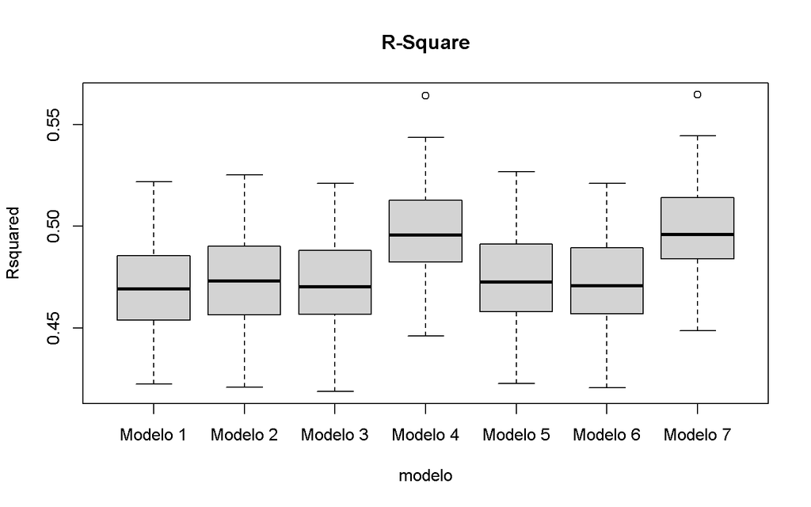

```r
## Pruebo los mejores de cada con validacion cruzada repetida
total<-c()
modelos<-sapply(list(modeloManual,modeloStepAIC,modeloStepBIC,modeloStepBIC_int,
                     modeloStepAIC_trans,modeloStepBIC_trans,modeloStepBIC_transInt),formula)
for (i in 1:length(modelos)){
  set.seed(1712)
  vcr<-train(as.formula(modelos[[i]]), data = data_train,
             method = "lm",
             trControl = trainControl(method="repeatedcv", number=5, repeats=20,
                                      returnResamp="all")
  )
  total<-rbind(total,cbind(vcr$resample[,1:2],modelo=rep(paste("Modelo",i),
                                                         nrow(vcr$resample))))
}
boxplot(Rsquared~modelo,data=total,main="R-Square")
```

```r
aggregate(Rsquared~modelo, data = total, mean) #el 4 y el 7 son mejores
```

```
##     modelo  Rsquared
## 1 Modelo 1 0.4696545
## 2 Modelo 2 0.4730673
## 3 Modelo 3 0.4714204
## 4 Modelo 4 0.4967268
## 5 Modelo 5 0.4735364
## 6 Modelo 6 0.4722320
## 7 Modelo 7 0.4974568
```

```r
aggregate(Rsquared~modelo, data = total, sd)
```

```
##     modelo   Rsquared
## 1 Modelo 1 0.02033351
## 2 Modelo 2 0.02061839
## 3 Modelo 3 0.02054697
## 4 Modelo 4 0.02123094
## 5 Modelo 5 0.02045953
## 6 Modelo 6 0.02017312
## 7 Modelo 7 0.02094105
```

```r
#vemos el número de parametros
length(coef(modeloStepBIC_int))
```

```
## [1] 34
```

```r
length(coef(modeloStepBIC_transInt))
```

```
## [1] 35
```

```r
# El primero tiene dos interacciones, el segundo una tranformación y azucar_tree

formula(modeloStepBIC_int)
```

```
## varObjCont ~ Clasificacion + Etiqueta + CalifProd_cont + Azucar_tree +
##     Acidez + Alcohol + Clasificacion:Etiqueta + Clasificacion:CalifProd_cont
```

```r
formula(modeloStepBIC_transInt)
```

```
## varObjCont ~ Clasificacion + Etiqueta + CalifProd_cont + sqrxAcidez +
##     Azucar_tree + Alcohol + sqrtxaleatorio2 + Clasificacion:Etiqueta +
##     Clasificacion:CalifProd_cont
```

## Esquema de selección aleatoria de variables

La idea que hay detrás de la selección aleatoria de variables, es la de someter a la función *step()* a muchas pruebas de robustez. Para ello, no es descabellado pensar que si le pedimos a step que trabaje con submuestras de los datos que contienen distintas observaciones cada vez, la selección de variables no estará condicionada por el conjunto de entrenamiento o no sobreajustará al mismo.

Lo que hacemos es repetir (de nuevo empirismo) el proceso clásico varias veces con distintos registros y evaluamos la estabilidad de los resultados. Parece lógico que si una selección de variables se mantiene inalterada en distintos conjuntos de observaciones, ese set de variables es robusto en capacidad de generalización.

Es tan simple como generar un bucle que repita el proceso *step()* con submuestras de datos, una vez generados se crea un dataframe de fórmulas y se cuenta cuantas veces aparece cada una. Se presenta una tabla de frecuencias para la valoración final.

La guardaremos en el objeto fr para poder acceder a las fórmulas más frecuentes posteriormente.

```r
## Seleccion aleatoria

rep<-20
prop<-0.7
modelosGenerados<-c()
for (i in 1:rep){
  set.seed(12345+i)
  subsample<-data_train[sample(1:nrow(data_train),prop*nrow(data_train),replace = T),]
  full<-lm(formIntT,data=subsample)
  null<-lm(varObjCont~1,data=subsample)
  modeloAux<-step(null,scope=list(lower=null,upper=full),direction="both",trace=0,k=log(nrow(subsample)))
  modelosGenerados<-c(modelosGenerados,paste(sort(unlist(strsplit(as.character(formula(modeloAux))[3]," [+] "))),collapse = "+"))
}
(freq(modelosGenerados,sort="dec")->fr)
```

```
##                                                                                                                                       n
## Azucar_tree+CalifProd_cont+Clasificacion+Clasificacion:Etiqueta+Etiqueta                                                              3
## Azucar_tree+CalifProd_cont+Clasificacion+Clasificacion:Etiqueta+Etiqueta+sqrxAcidez                                                   2
## CalifProd_cont+Clasificacion+Clasificacion:CalifProd_cont+Clasificacion:Etiqueta+Etiqueta                                             2
## Acidez+Azucar_tree+CalifProd_cont+Clasificacion+Clasificacion:CalifProd_cont+Clasificacion:Etiqueta+CloruroSodico+Etiqueta            1
## Alcohol+aleatorio2+CalifProd_cont+Clasificacion+Clasificacion:CalifProd_cont+Clasificacion:Etiqueta+CloruroSodico+Etiqueta+sqrxAcidez 1
## Alcohol+Azucar_tree+CalifProductor+Clasificacion+Clasificacion:Etiqueta+Etiqueta+sqrtxaleatorio2+sqrxAcidez                           1
## Alcohol+CalifProd_cont+Clasificacion+Clasificacion:CalifProd_cont+Clasificacion:Etiqueta+CloruroSodico+Etiqueta+sqrxAcidez+sqrxpH     1
## Alcohol+CalifProd_cont+Clasificacion+Clasificacion:Etiqueta+Etiqueta                                                                  1
## aleatorio2+CalifProd_cont+Clasificacion+Clasificacion:Etiqueta+Etiqueta                                                               1
## Azucar_tree+CalifProd_cont+Clasificacion+Clasificacion:CalifProd_cont+Clasificacion:Etiqueta+CloruroSodico+Etiqueta                   1
## CalifProd_cont+Clasificacion+Clasificacion:CalifProd_cont+Clasificacion:Etiqueta+CloruroSodico+Etiqueta                               1
## CalifProd_cont+Clasificacion+Clasificacion:CalifProd_cont+Clasificacion:Etiqueta+Etiqueta+sqrtxaleatorio2                             1
## CalifProd_cont+Clasificacion+Clasificacion:Etiqueta+CloruroSodico+Etiqueta+logxaleatorio+pH+sqrxAcidez                                1
## CalifProd_cont+Clasificacion+Clasificacion:Etiqueta+CloruroSodico+Etiqueta+sqrxAcidez                                                 1
## CalifProd_cont+Clasificacion+Clasificacion:Etiqueta+Etiqueta+pH+sqrxAcidez                                                            1
## CalifProd_cont+Clasificacion+Clasificacion:Etiqueta+Etiqueta+sqrxAcidez+sqrxpH                                                        1
##                                                                                                                                        %
## Azucar_tree+CalifProd_cont+Clasificacion+Clasificacion:Etiqueta+Etiqueta                                                              15
## Azucar_tree+CalifProd_cont+Clasificacion+Clasificacion:Etiqueta+Etiqueta+sqrxAcidez                                                   10
## CalifProd_cont+Clasificacion+Clasificacion:CalifProd_cont+Clasificacion:Etiqueta+Etiqueta                                             10
## Acidez+Azucar_tree+CalifProd_cont+Clasificacion+Clasificacion:CalifProd_cont+Clasificacion:Etiqueta+CloruroSodico+Etiqueta             5
## Alcohol+aleatorio2+CalifProd_cont+Clasificacion+Clasificacion:CalifProd_cont+Clasificacion:Etiqueta+CloruroSodico+Etiqueta+sqrxAcidez  5
## Alcohol+Azucar_tree+CalifProductor+Clasificacion+Clasificacion:Etiqueta+Etiqueta+sqrtxaleatorio2+sqrxAcidez                            5
## Alcohol+CalifProd_cont+Clasificacion+Clasificacion:CalifProd_cont+Clasificacion:Etiqueta+CloruroSodico+Etiqueta+sqrxAcidez+sqrxpH      5
## Alcohol+CalifProd_cont+Clasificacion+Clasificacion:Etiqueta+Etiqueta                                                                   5
## aleatorio2+CalifProd_cont+Clasificacion+Clasificacion:Etiqueta+Etiqueta                                                                5
## Azucar_tree+CalifProd_cont+Clasificacion+Clasificacion:CalifProd_cont+Clasificacion:Etiqueta+CloruroSodico+Etiqueta                    5
## CalifProd_cont+Clasificacion+Clasificacion:CalifProd_cont+Clasificacion:Etiqueta+CloruroSodico+Etiqueta                                5
## CalifProd_cont+Clasificacion+Clasificacion:CalifProd_cont+Clasificacion:Etiqueta+Etiqueta+sqrtxaleatorio2                              5
## CalifProd_cont+Clasificacion+Clasificacion:Etiqueta+CloruroSodico+Etiqueta+logxaleatorio+pH+sqrxAcidez                                 5
## CalifProd_cont+Clasificacion+Clasificacion:Etiqueta+CloruroSodico+Etiqueta+sqrxAcidez                                                  5
## CalifProd_cont+Clasificacion+Clasificacion:Etiqueta+Etiqueta+pH+sqrxAcidez                                                             5
## CalifProd_cont+Clasificacion+Clasificacion:Etiqueta+Etiqueta+sqrxAcidez+sqrxpH                                                         5
```

[output cut: 17 more lines]

```r
# Guardo la tabla de frecuancias para luego seleccionar los más relevantes y probarlos
```

Podemos seleccionar los 3 mejores modelos por ejemplo y enfrentarlos en la comparación final.

## Esquema de selección de variables por Lasso

Lasso es en realidad un método de regresión en sí mismo, cuya particularidad reside en que la optimización por mínimos cuadrados/máxima verosimilitud se ve restringida por una condición que no existía en regresiones ordinarias. Esta condición aplica al sumatorio del valor de los parámetros del modelo, esta restricción hace que el método pueda ser considerado como un selector de variables directamente.

No es el objetivo entrar en el proceso matemático subyacente a esta técnica y nos conformaremos con aplicarla como posible método de selección de variables. Si conviene saber que Lasso maneja un parámetro lambda que es encargado de cuantificar el peso que la restricción sobre los parámetros debe tener para una solución con error de estimación controlado. De esta forma, el primer paso es buscar ese valor de lambda (usualmente el que se encuentra a 1 desviación típica de mínimo para penalizar lo suficiente pero no tanto como para que el error se dispare) y con el evaluar el modelo por validación cruzada.

La función *cv.glmnet()* permite hacer esta operación, si bien requiere del uso previo de la función *model.matrix()* que realiza una extensión de las variables nominales a *dummies* y deja el archivo como lo necesita este paquete.

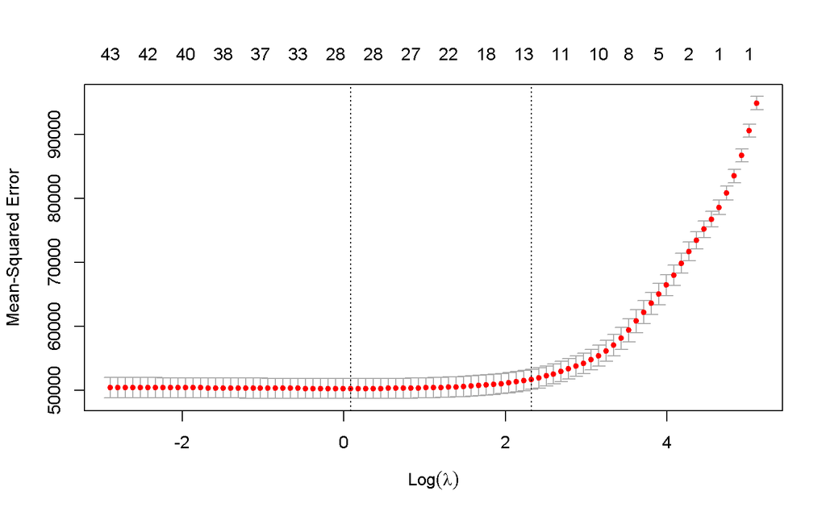

```r
## LASSO, lo hacemos sin interacciones pues, de lo contrario, puede coger interacciones y no las variables que las forman
y <- as.double(as.matrix(data_train[, 33]))
x<-model.matrix(varObjCont~., data=data_train)[,-1]#no cambiar el -1
set.seed(1712)
cv.lasso <- cv.glmnet(x,y,nfolds=5)
plot(cv.lasso)
```

Este es el comportamiento de lambda y el intervalo de 1se. Mostramos lo coeficiente.

```r
(betas<-coef(cv.lasso, s=cv.lasso$lambda.1se))
```

```
## 45 x 1 sparse Matrix of class "dgCMatrix"
##                                     1
## (Intercept)               532.7708606
## ID                          .
## Acidez                      .
## AcidoCitrico                .
## Azucar                      .
## CloruroSodico               .
## Densidad                    .
## pH                          .
## Sulfatos                    .
## Alcohol                     .
## EtiquetaM                 -87.3972092
## EtiquetaMB                 51.6817824
## EtiquetaMM               -130.6048356
## EtiquetaR                 -26.8355561
## CalifProductor2             .
## CalifProductor3             .
## CalifProductor4             .
## CalifProductor5-12        -29.9073524
## Clasificacion**           108.5724231
## Clasificacion***          211.4545944
## Clasificacion****         296.1594917
## ClasificacionDesconocido -222.2473615
## Region2                     .
## Region3                     .
## PrecioBotella               .
## CalifProd_cont            -20.5656712
## prop_missings               .
## aleatorio                   .
## aleatorio2                  .
## cuartaxID                   .
## sqrxAcidez                 -0.5406571
## expxAcidoCitrico            .
## logxAzucar                  .
## sqrxCloruroSodico           .
## xDensidad                   .
## sqrxpH                      .
## sqrtxSulfatos               .
## xAlcohol                    .
## xPrecioBotella              .
## xCalifProd_cont             .
## logxprop_missings           .
## logxaleatorio               .
## sqrtxaleatorio2             .
## Azucar_tree1.64-4.58        .
## Azucar_tree>4.58            .
```

Todos aquellos que aparecen con un . han sido descartados del modelo n base al cumplimiento de la restricción para ese valor de lambda que se suele considerar óptimo.

Por otra parte, al extenderse las nominales en dummies es posible que aparezcan efectos d niveles independientemente de la consideración de otros de la misma variable. Este es el caso de calificación de productor nominal en su categoría 5-12.

## Comparativa final y selección del modelo ganador

Finalmente vamos a considerar los modelos que parecen mejores en selección automática de variables “clásica”, aleatoria y lasso junto con el modelo manual de referencia y sencillo.

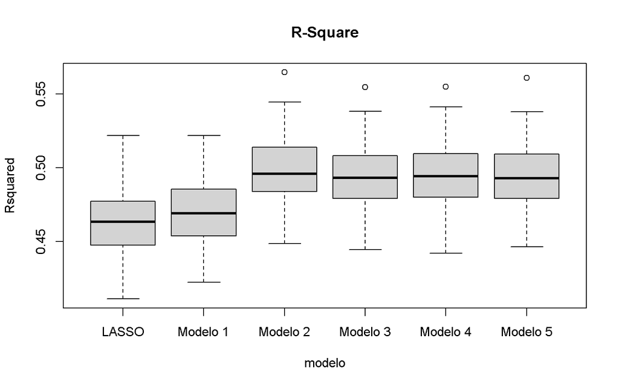

```r
## Comparación final, tomo el ganador de antes y los nuevos candidatos
total2<-c()
modelos2<-c(formula(modeloManual),formula(modeloStepBIC_transInt),
            as.formula(paste('varObjCont ~', rownames(fr)[1])),
            as.formula(paste('varObjCont ~', rownames(fr)[2])),
            as.formula(paste('varObjCont ~', rownames(fr)[3])))
for (i in 1:length(modelos2)){
  set.seed(1712)
  vcr<-train(as.formula(modelos2[[i]]), data = data_train,
             method = "lm",
             trControl = trainControl(method="repeatedcv", number=5, repeats=20,
                                      returnResamp="all")
  )
  total2<-rbind(total2,cbind(vcr$resample[,1:2],modelo=rep(paste("Modelo",i),
                                                         nrow(vcr$resample))))
}
set.seed(1712)
lassovcr <- train(varObjCont ~ ., data = data_train,
                  method = "glmnet",
                  tuneGrid=expand.grid(.alpha=1,.lambda=cv.lasso$lambda.1se),
                  trControl = trainControl(method="repeatedcv", number=5, repeats=20,
                                           returnResamp="all")
)
total2<-rbind(total2,cbind(lassovcr$resample[,1:2],modelo=rep("LASSO",
                                                         nrow(vcr$resample))))

boxplot(Rsquared~modelo,data=total2,main="R-Square") #el lasso funciona peor
```

```r
aggregate(Rsquared~modelo, data = total2, mean)
```

```
##     modelo  Rsquared
## 1    LASSO 0.4629490
## 2 Modelo 1 0.4696545
## 3 Modelo 2 0.4974568
## 4 Modelo 3 0.4928006
## 5 Modelo 4 0.4937601
## 6 Modelo 5 0.4939774
```

```r
aggregate(Rsquared~modelo, data = total2, sd)
```

```
##     modelo   Rsquared
## 1    LASSO 0.02099267
## 2 Modelo 1 0.02033351
## 3 Modelo 2 0.02094105
## 4 Modelo 3 0.02101875
## 5 Modelo 4 0.02092692
## 6 Modelo 5 0.02121515
```

```r
#Una vez decidido el mejor modelo, hay que evaluarlo (ver final del CódigoRegLineal)

#Este código se puede aplicar a regresión logística con pequeñas modificaciones (básicamente cambiar lm() por glm(),
#con la opción family=binomial) Para ello, ver código del pdf RegresiónLogísticaconR
```

En este punto tenemos un modelo manual generado en la práctica 2 que resultaba sencillo y no muy lejano en capacidad predictiva con respecto a otros mas complejos. En esta parte de selección de variables, todos los métodos excepto Lasso abogan por mantener la interacción de las variables clasificación y etiqueta con un ligera mejora de la capacidad predictiva pero, a su vez, un importante aumento en el número de parámetros.

En validación cruzada estamos en niveles de R2 iguales que los de los modelos complejos propuestos en la selección manual con lo que, en términos de mejora de la capacidad predictiva, los métodos de selección de variables no ha supuesto en este caso concreto una mejora sustancial.

Nos encontramos ante el mismo dilema que en la práctica 2. Decidirnos por el modelo manual sencillo o ganar 3 centésimas de R eligiendo el modelo con la interacción Clasificación:Etiqueta… En caso de escoger la segunda de las opciones, sería conveniente revisar el modelo y realizar la unión de categorías de clasificación (o probar con etiqueta..) de modo que no aparezcan efectos con NA en las estimaciones con una pérdida de pocas milésimas en términos de R2.